# Statistical Learning

### By: Jose Velasquez Sosa

In this notebook we will inspect the dataset “uni.csv” which contains data for different US universities.  
This dataset contains the following columns:  
**• Private**: Public/private indicator (possible values: yes/no)  
**• Apps**: Number of applications received  
**• Accept**: Number of applicants accepted  
**• Enroll**: Number of new students enrolled  
**• Top10perc**: New students from top 10 % of high school class  
**• Top25perc**: New students from top 25 % of high school class  
**• F.Undergrad** : Number of full-time undergraduates  
**• P.Undergrad** : Number of part-time undergraduates  
**• Outstate**: Out-of-state tuition  
**• Room.Board**: Room and board costs  
**• Books**: Estimated book costs  
**• Personal**: Estimated personal spending  
**• PhD**: Percent of faculty with Ph.D.’s  
**• Terminal**: Percent of faculty with terminal degree  
**• S.F.Ratio**: Student/faculty ratio  
**• perc.alumni** : Percent of alumni who donate  
**• Expend**: Instructional expenditure per student  
**• Grad.Rate**: Graduation rate

```python
# import main libraries for EDA
import pandas as pd
import matplotlib.pyplot as plt
import seaborn as sns
import numpy as np

# load csv in a DataFrame    (declaring type to facilitate IDE use)
df: pd.DataFrame = pd.read_csv("res/uni.csv", sep=";", index_col=0)
```

#### Exploratory Data Analysis

```python
# Check the datatype of each column
df.dtypes
```

```
Private         object
Apps             int64
Accept           int64
Enroll           int64
Top10perc        int64
Top25perc        int64
F.Undergrad      int64
P.Undergrad      int64
Outstate         int64
Room.Board       int64
Books            int64
Personal         int64
PhD              int64
Terminal         int64
S.F.Ratio      float64
perc.alumni      int64
Expend           int64
Grad.Rate      float64
dtype: object
```

We see that the *Private* column is of type object. Therefore we have to check that all of the objects in the colum are valid.

```python
df.Private.unique()
```

```
array(['Yes', 'No', 'NB'], dtype=object)
```

We see that there are some "NB" values. Let's how many and which universities are the ones with this value.

```python
df[df.Private == 'NB'].index
```

```
Index(['Concordia College at St. Paul', 'Concordia Lutheran College',
       'Concordia University CA', 'Concordia University'],
      dtype='object')
```

We see that there are four entries and they are all part of Concordia University or College, which after a quick research we see that they are private institutions.

```python
df.loc[df.Private == 'NB', 'Private'] = 'Yes'
df.Private.unique()
```

```
array(['Yes', 'No'], dtype=object)
```

Now that we will cast this column to a boolea datatype as it will make it easier to handle later on in any type of analysis.

```python
df["Private"] = df["Private"].apply(lambda x: True if x == "Yes" else False)
df.dtypes
```

```
Private           bool
Apps             int64
Accept           int64
Enroll           int64
Top10perc        int64
Top25perc        int64
F.Undergrad      int64
P.Undergrad      int64
Outstate         int64
Room.Board       int64
Books            int64
Personal         int64
PhD              int64
Terminal         int64
S.F.Ratio      float64
perc.alumni      int64
Expend           int64
Grad.Rate      float64
dtype: object
```

Now that we have all our columns are basic datatype we can look for any null value and perform a better EDA.

```python
df.isnull().any()
```

```
Private        False
Apps           False
Accept         False
Enroll         False
Top10perc      False
Top25perc      False
F.Undergrad    False
P.Undergrad    False
Outstate       False
Room.Board     False
Books          False
Personal       False
PhD            False
Terminal       False
S.F.Ratio      False
perc.alumni    False
Expend         False
Grad.Rate       True
dtype: bool
```

We see that the only column with a null values is the **Grad.Rate** column. Let's have a closer look to decide how we will handle these null values

```python
df[df['Grad.Rate'].isnull()].index
```

```
Index(['Western Washington University', 'Westfield State College',
       'Westminster College MO'],
      dtype='object')
```

```python
df.loc['Western Washington University', "Grad.Rate"] = 71.4
df.loc['Westfield State College', "Grad.Rate"] = 62.7
df.loc['Westminster College MO', "Grad.Rate"] = 65.9
```

Now that we have dealt with all missing values we will look at the distribution of the different columns and see if there are any outliers or unexpected values in the distributions

##### Apps

As this column will be our target value, we want to make sure that all of the entries in the data are valid. In addition, we want to reduce the number of outliers, if any.

```
count      777.000000
mean      3001.638353
std       3870.201484
min         81.000000
25%        776.000000
50%       1558.000000
75%       3624.000000
max      48094.000000
Name: Apps, dtype: float64
```

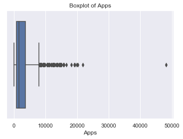

```python
sns.set(style="darkgrid")
sns.boxplot(df.Apps).set_title("Boxplot of Apps")
df.Apps.describe()
```

Firstly, we see in the described statistics that the the minimum value is 81; therefore, no negative values. Additionally, we see in the boxplot above that there is a large number of outliers. However, there is one entry that is far beyond the distribution. Let's see how many outliers there are in the the Apps data. If there is a subtantiale amount, it might be necessary to apply some transformation to this column in order to proceed with statistical learning.

```python
def get_outlier_index(frame: pd.DataFrame, col: str) -> pd.Index:
    """
    A function that returns the indices of the outliers of a column in a dataframe
    :param frame: The DataFrame from which the indices and the column will be used
    :param col: The column's name
    :return: The Index object of the outliers of the column
    """
    column = frame[col]
    q1, q3 = np.percentile(column.values, [25, 75])
    iqr = q3 - q1
    l_bound = q1 - (iqr * 1.5)
    u_bound = q3 + (iqr * 1.5)
    return frame[(frame[col] < l_bound) | (frame[col] > u_bound)].index


len(get_outlier_index(df, 'Apps'))
```

```
70
```

70 outliers out of the 777 entries is quite a high number of the data. Therfore, we will make a *ln_Apps* column for when we want to use this column for statistical learning purposes.

```
Text(0.5,1,'Boxplot of ln(Applications)')
```

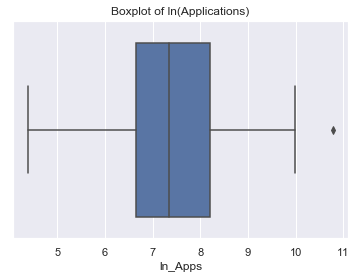

```python
import math
df["ln_Apps"] = df["Apps"].apply(math.log)
sns.boxplot(df.ln_Apps).set_title("Boxplot of ln(Applications)")
```

We see that even after the transformation, there is still one outlier. Therefore, we will ommit this entry when we perform statistical learning later on.

##### Accept & Enroll

Now we will look that there are no negative values and that the number of accepted students is less or equal to the ones that applied. Also check if the enrolled students is less or equal to the ones that got accepted.

```python
df.loc[(df["Apps"] < df["Accept"]) | (df["Accept"] < df["Enroll"]), ['Apps', 'Accept', 'Enroll']]
```

|  | Apps | Accept | Enroll |
| --- | --- | --- | --- |
| Cumberland College | 995 | 789 | 4398 |
| D'Youville College | 866 | 619 | 7157 |

We see that there are two universities that do not, meet the required logic. Therefore we will erase them from the DataFrame in order to mantain logical consistancy.

```python
df = df[-(df["Accept"] < df["Enroll"])]
```

```python
df.Accept.describe()
```

```
count      775.000000
mean      2022.197419
std       2453.362385
min         72.000000
25%        602.500000
50%       1110.000000
75%       2432.000000
max      26330.000000
Name: Accept, dtype: float64
```

```python
df.Enroll.describe()
```

```
count     775.000000
mean      781.269677
std       930.004147
min        35.000000
25%       242.500000
50%       437.000000
75%       902.500000
max      6392.000000
Name: Enroll, dtype: float64
```

##### Top 10% & 25%

For this columns we will do a similar thing as for the ones of accepted and enrolled

```python
df.loc[(df.Enroll < df.Top25perc) | (df.Top25perc < df.Top10perc), ['Enroll', 'Top25perc', 'Top10perc']]
```

|  | Enroll | Top25perc | Top10perc |
| --- | --- | --- | --- |
| Capitol College | 35 | 52 | 10 |
| Christendom College | 51 | 71 | 33 |
| Wilson College | 46 | 50 | 16 |

```python
df = df[-(df['Enroll'] < df['Top25perc'])]
df.Top25perc.describe()
```

```
count    772.000000
mean      55.812176
std       19.854718
min        9.000000
25%       41.000000
50%       54.000000
75%       69.000000
max      100.000000
Name: Top25perc, dtype: float64
```

```python
df.Top10perc.describe()
```

```
count    772.000000
mean      27.603627
std       17.676687
min        1.000000
25%       15.000000
50%       23.000000
75%       35.250000
max       96.000000
Name: Top10perc, dtype: float64
```

### Statistical Learning

```python
from sklearn.model_selection import cross_val_score
from sklearn.linear_model import LinearRegression, Lasso, Ridge
```

```python
def run_cv_on_model(frame: pd.DataFrame, target: str, estimator, alphas)->pd.DataFrame:
    heads = list(frame)
    heads.remove("Apps")
    heads.remove(target)
    x = frame[heads].values.reshape(-1, len(heads))
    y = frame[target].values
    alphas_score = pd.DataFrame()
    for alpha in alphas:
        model = estimator(alpha=alpha)
        alphas_score[str(alpha)] = cross_val_score(estimator=model, X=x, y=y, cv=10, pre_dispatch="2*n_jobs")
    return alphas_score


df_without_outlier = df[-(df['Apps'] == 48094)]
```

```
Text(0.5,1,'R^2 score for different α values, Lasso regression')
```

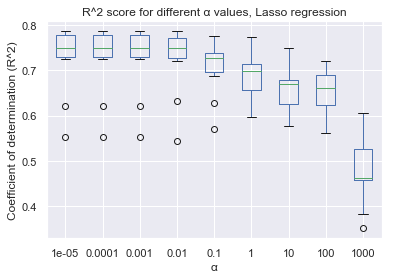

```python
scores_lasso: pd.DataFrame = run_cv_on_model(df_without_outlier, "ln_Apps", Lasso,
                                             [1e-5, 0.0001, 0.001, 0.01, 0.1, 1, 10, 100, 1000])
ax_lasso = scores_lasso.boxplot()
ax_lasso.set_xlabel("α")
ax_lasso.set_ylabel("Coefficient of determination (R^2)")
ax_lasso.set_title("R^2 score for different α values, Lasso regression")
```

```
Text(0.5,1,'R^2 score for different α values, Ridge regression')
```

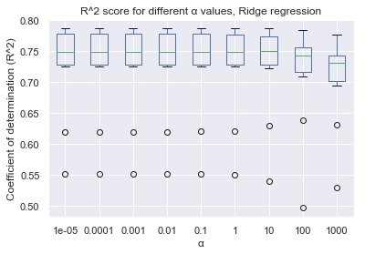

```python
scores_ridge: pd.DataFrame = run_cv_on_model(df_without_outlier, "ln_Apps", Ridge,
                                             [1e-5, 0.0001, 0.001, 0.01, 0.1, 1, 10, 100, 1000])
ax_ridge = scores_ridge.boxplot()
ax_ridge.set_xlabel("α")
ax_ridge.set_ylabel("Coefficient of determination (R^2)")
ax_ridge.set_title("R^2 score for different α values, Ridge regression")
```